## Course: VISUAL ANALYTICS FOR POLICY AND MANAGEMENT

### Prof. José Manuel Magallanes, PhD

- Visiting Professor of Computational Policy at Evans School of Public Policy and Governance, and eScience Institute Senior Data Science Fellow, University of Washington.
- Professor of Government and Political Methodology, Pontificia Universidad Católica del Perú.

# Opening data files

Let’s open this file that includes the *democracy index*, the *human development index*, and the *military expenditures as share of gdp*, all at the country level:

```r
linkCSV='https://github.com/EvansDataScience/VAforPM_Spatial/raw/main/merged_data.csv'

dataCSV=read.csv(linkCSV)
```

This is what we have:

```r
str(dataCSV)
```

```
## 'data.frame':    139 obs. of  5 variables:
##  $ ISO3      : chr  "AFG" "AGO" "ALB" "ARE" ...
##  $ Country   : chr  "Afghanistan" "Angola" "Albania" "United Arab Emirates" ...
##  $ DemoIndex : num  2.85 3.66 6.08 2.7 6.95 5.35 8.96 8.16 2.68 2.14 ...
##  $ HDI       : num  0.511 0.581 0.795 0.89 0.845 0.776 0.944 0.922 0.756 0.433 ...
##  $ mil_expend: num  1.2 1.6 1.47 5.7 0.7 4.9 1.9 0.7 4 1.8 ...
```

Let’s explore the behavior of each numerical variable:

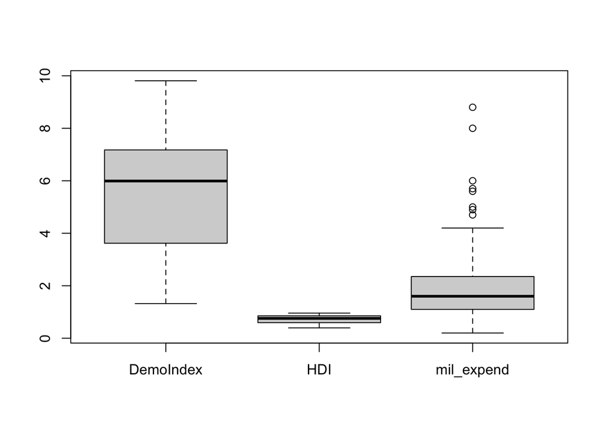

```r
boxplot(dataCSV[,c('DemoIndex','HDI','mil_expend')])
```

The data ranges are different. We can try **standardization**:

```r
dataCSV$HDI_S=as.vector(scale(dataCSV$HDI))
dataCSV$DEM_S=as.vector(scale(dataCSV$DemoIndex))
dataCSV$MIL_S=as.vector(scale(dataCSV$mil_expend))
```

Let’s cluster the data using **pam** again:

```r
set.seed(123)

library(cluster)
vars=c('HDI_S','DEM_S','MIL_S')#variables needed

distMatrix=cluster::daisy(dataCSV[,vars])

res.pam=cluster::pam(x=distMatrix,
                     k = 3,
                     cluster.only = F)
```

Let’s save the cluster info into the data frame:

```r
dataCSV$cluster=as.factor(res.pam$clustering)
```

Check order:

```r
theVars=c('HDI_S','DEM_S','MIL_S','cluster')
aggregate(.~cluster,
          data=dataCSV[,theVars],
          FUN=median)
```

```
##   cluster      HDI_S      DEM_S      MIL_S
## 1       1 -1.0335191 -0.8167713 -0.4551644
## 2       2  0.8330751  0.7503949 -0.3140832
## 3       3  0.2979423 -0.9108471  1.4494313
```

We could recode so that number ordering make sense:

```r
dataCSV$cluster=factor(dataCSV$cluster,
                           levels=c(1,3,2),
                           labels=c("low","mid","best"),
                           ordered=T)
```

Now, let me open the map:

```r
linkMap="https://github.com/EvansDataScience/VAforPM_Spatial/raw/main/worldMap.geojson"

library(sf)
```

```r
mapWorld=read_sf(linkMap)
```

This is the data that came with the map:

```r
# see data in map
head(mapWorld)
```

```
## Simple feature collection with 6 features and 11 fields
## geometry type:  MULTIPOLYGON
## dimension:      XY
## bbox:           xmin: -61.88722 ymin: -18.01639 xmax: 50.37499 ymax: 42.61805
## geographic CRS: WGS 84
## # A tibble: 6 x 12
##   FIPS  ISO2  ISO3     UN NAME        AREA POP2005 REGION SUBREGION    LON   LAT
##   <chr> <chr> <chr> <int> <chr>      <int>   <int>  <int>     <int>  <dbl> <dbl>
## 1 AC    AG    ATG      28 Antigua …     44  8.30e4     19        29 -61.8   17.1
## 2 AG    DZ    DZA      12 Algeria   238174  3.29e7      2        15   2.63  28.2
## 3 AJ    AZ    AZE      31 Azerbaij…   8260  8.35e6    142       145  47.4   40.4
## 4 AL    AL    ALB       8 Albania     2740  3.15e6    150        39  20.1   41.1
## 5 AM    AM    ARM      51 Armenia     2820  3.02e6    142       145  44.6   40.5
## 6 AO    AO    AGO      24 Angola    124670  1.61e7      2        17  17.5  -12.3
## # … with 1 more variable: geometry <MULTIPOLYGON [°]>
```

The map also shows important information that common data frames, especially the CRS. The CRS tells information about the map projection. In case you want to produce other maps you need that these have the same CRS.

Let’s add our data to the map by merging:

```r
mapWorldVars=merge(mapWorld, #map first
                   dataCSV,
                   by='ISO3')
```

We can map the data now using *ggplot*. Let me do it by layers:

1. Base layer:

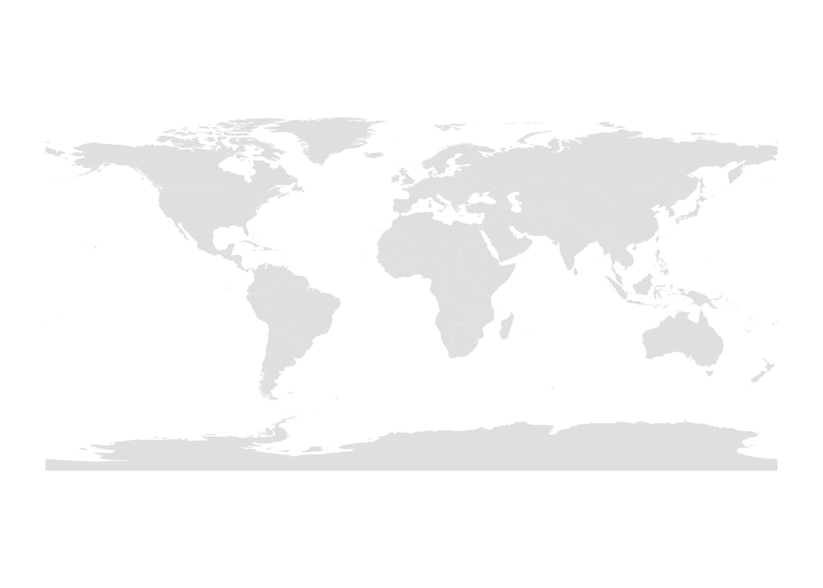

```r
library(ggplot2)
# plot original map
base=ggplot(data=mapWorld) + geom_sf(fill='grey90',
                                     color=NA) + theme_classic()

base #base map
```

2. Data layer:

This will be plot on top of the previous. Whatever is still in grey means a country has no information:

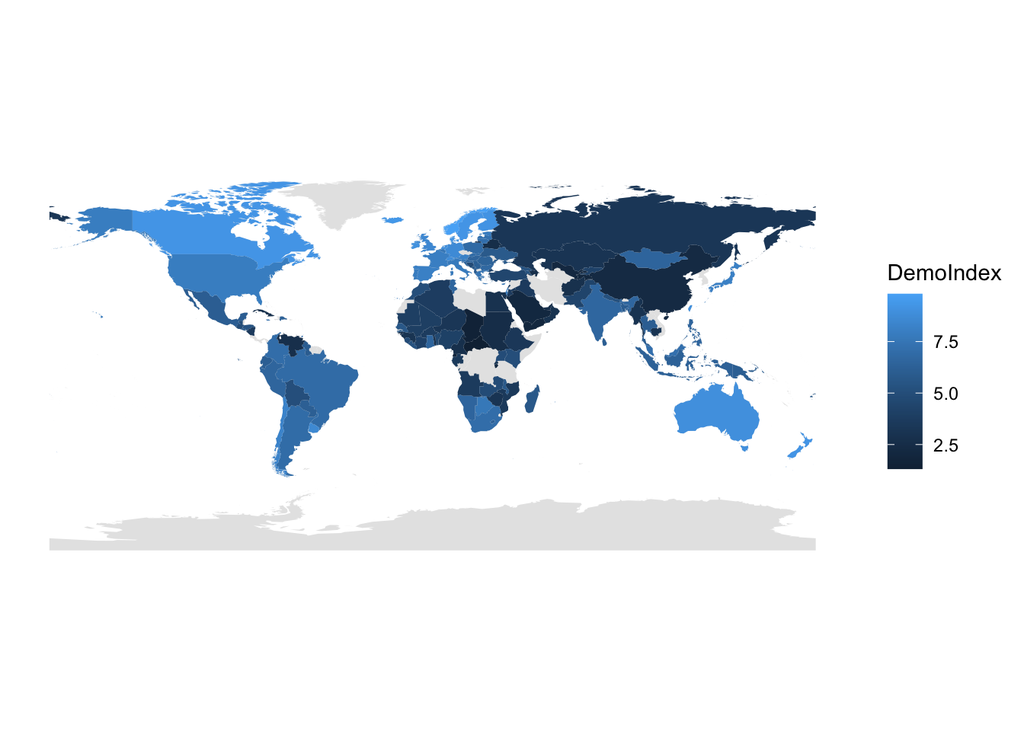

```r
colMap= base + geom_sf(data=mapWorldVars,
                       aes(fill=DemoIndex),
                       color=NA)
colMap
```

We can alter the color sequence:

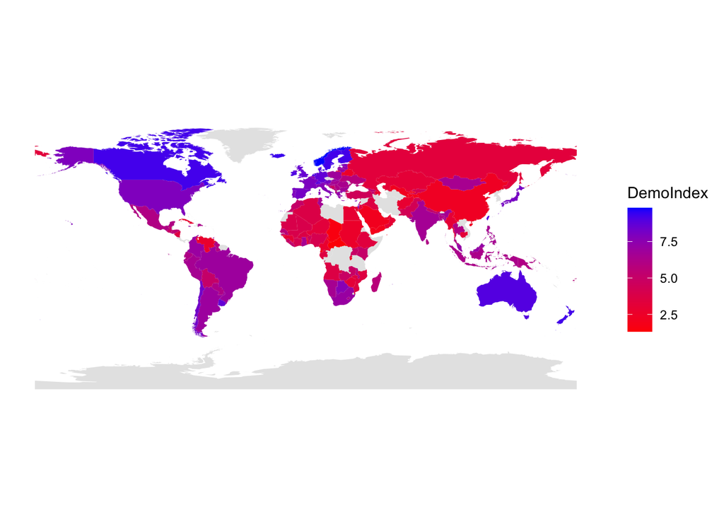

```r
colMap + scale_fill_gradient(low = 'red',
                             high= 'blue')
```

Now paint the countries using the cluster information (ggplot decides color):

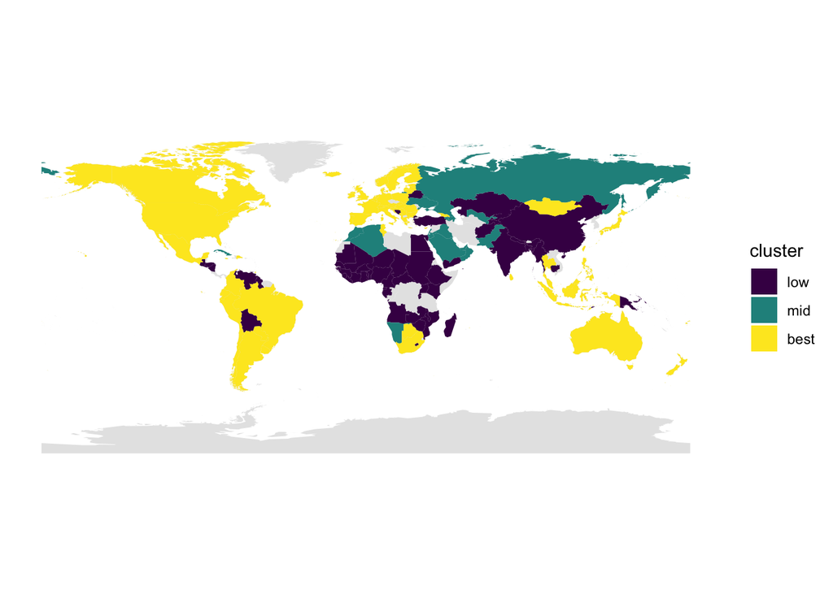

```r
clusterMap= base + geom_sf(data=mapWorldVars,
                           aes(fill=cluster),
                           color=NA) # color of border
clusterMap
```

Now we choose the palette (get it from [here](http://colorbrewer2.org/)):

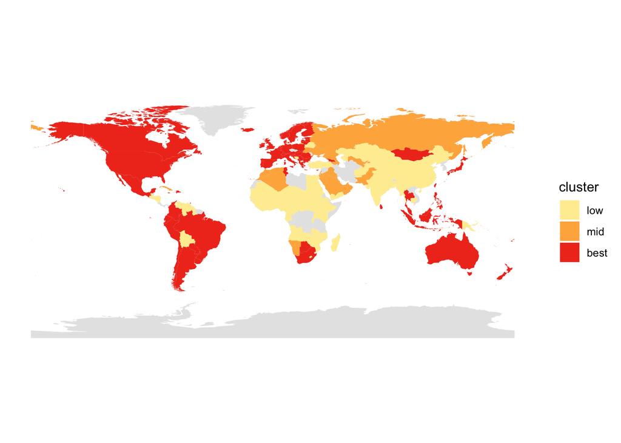

```r
clusterMap+ scale_fill_brewer(palette ='YlOrRd')
```

Some more customization:

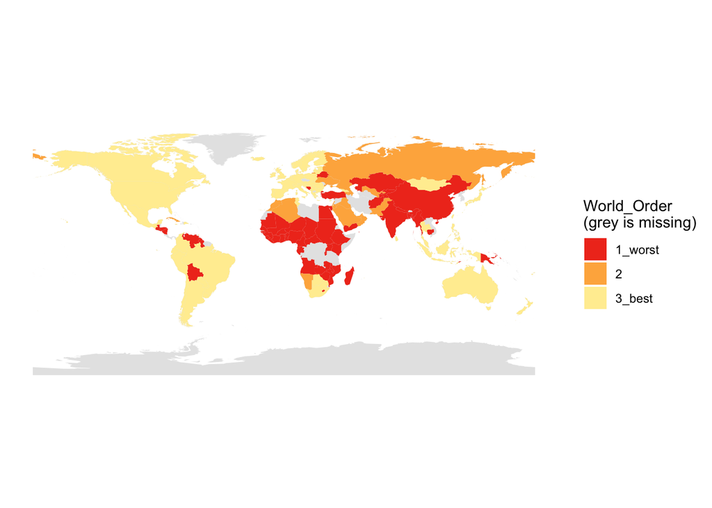

```r
#previously
theLegLabels=c('1_worst',2,'3_best')
theLegTitle="World_Order\n(grey is missing)"

#now
clusterMap+ scale_fill_brewer(palette ='YlOrRd',
                              direction = -1, # color order
                              labels=theLegLabels,
                              name=theLegTitle)
```

Let me make other map by bringing a data set on cities:

```r
library(rio)

linkCity="https://github.com/EvansDataScience/VAforPM_Spatial/raw/main/citiesloc.xlsx"


idxcity=import(linkCity)
```

The data on cities is known (it is a summary) but this files has some location info:

```r
str(idxcity)
```

```
## 'data.frame':    60 obs. of  9 variables:
##  $ city          : chr  "Abu Dhabi" "Amsterdam" "Athens" "Bangkok" ...
##  $ COUNTRY_ISO3  : chr  "ARE" "NLD" "GRC" "THA" ...
##  $ DIGITAL       : num  68.8 85.8 61.9 44.4 74.4 ...
##  $ HEALTH        : num  68.5 79.8 74.6 66.6 78.5 ...
##  $ INFRASTRUCTURE: num  91.4 96 82 68.3 96.6 ...
##  $ PERSONAL      : num  79 87.4 69 60.8 85.3 ...
##  $ lat           : num  24.5 52.4 38 13.8 41.4 ...
##  $ lng           : num  54.37 4.92 23.72 100.52 2.18 ...
##  $ population    : num  1000000 1031000 664046 17066000 4588000 ...
```

Let’s cluster as before:

```r
varsidx=c("DIGITAL","HEALTH","INFRASTRUCTURE","PERSONAL")

set.seed(123)
distMatrix2=cluster::daisy(idxcity[,varsidx])


res.pam2=pam(distMatrix2,
             k = 3,
             cluster.only = F)

idxcity$cluster=res.pam2$clustering
```

Let’s check the order:

```r
varsidx=c(varsidx,'cluster')
aggregate(data=idxcity[,varsidx],
          .~cluster,
          FUN=median)
```

```
##   cluster  DIGITAL   HEALTH INFRASTRUCTURE PERSONAL
## 1       1 60.56570 67.62942       79.43629 71.01911
## 2       2 82.11095 79.22623       92.75429 85.51684
## 3       3 54.60559 59.08553       60.42961 60.42329
```

We could improve the labels:

```r
idxcity$cluster=factor(idxcity$cluster,
                       levels=c(3,1,2),
                       labels=c("bad","middle",'good'),
                       ordered=T)
```

Let me use the location of the city to create a spatial points object:

```r
idxcity_sf = st_as_sf(idxcity,
                      coords = c("lng", "lat"),
                      crs = st_crs(mapWorldVars)) # shared
```

Now we have:

```r
head(idxcity_sf)
```

```
## Simple feature collection with 6 features and 8 fields
## geometry type:  POINT
## dimension:      XY
## bbox:           xmin: 2.1769 ymin: 13.75 xmax: 116.3914 ymax: 52.35
## geographic CRS: WGS 84
##        city COUNTRY_ISO3  DIGITAL   HEALTH INFRASTRUCTURE PERSONAL population
## 1 Abu Dhabi          ARE 68.77421 68.54043       91.36416 78.95145    1000000
## 2 Amsterdam          NLD 85.79071 79.79323       96.04870 87.42197    1031000
## 3    Athens          GRC 61.93823 74.57161       82.04507 69.03243     664046
## 4   Bangkok          THA 44.44312 66.63739       68.33223 60.79785   17066000
## 5 Barcelona          ESP 74.44147 78.54113       96.59329 85.28254    4588000
## 6   Beijing          CHN 65.37625 67.62942       74.48954 80.76429   19433000
##   cluster                geometry
## 1  middle POINT (54.3686 24.4781)
## 2    good    POINT (4.9166 52.35)
## 3  middle POINT (23.7161 37.9794)
## 4     bad  POINT (100.5167 13.75)
## 5    good  POINT (2.1769 41.3825)
## 6  middle POINT (116.3914 39.905)
```

As this is a spatial object let me add it on top of the basemap:

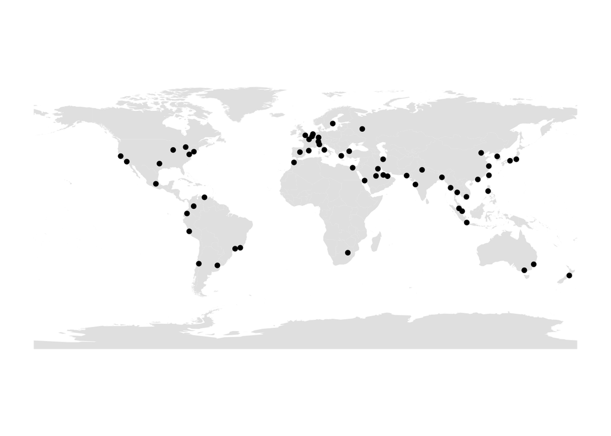

```r
base + geom_sf(data=idxcity_sf)
```

Finally:

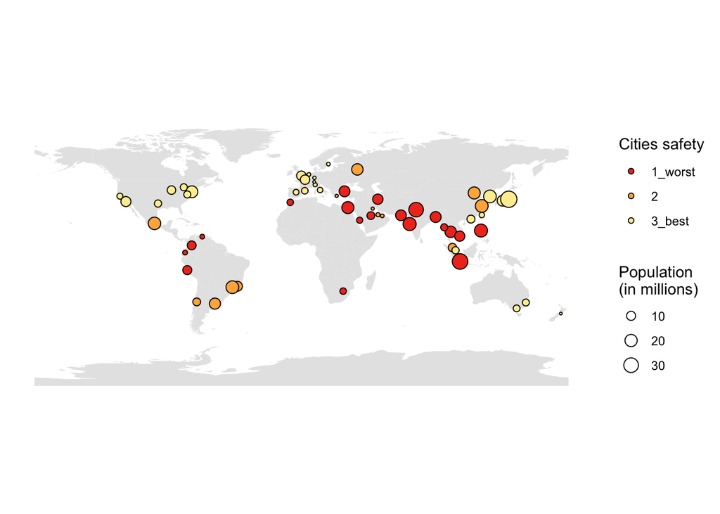

```r
#previously
fillLabels=c('1_worst',2,'3_best')
fillTitle="Cities safety"
nameSize="Population \n(in millions)"

points= base + geom_sf(data=idxcity_sf,
                       shape=21,
                       aes(fill=cluster,
                           size=population/1000000))
#now
points = points + scale_fill_brewer(palette ='YlOrRd',
                                direction = -1,
                                labels=fillLabels,
                                name=fillTitle)
points =points + scale_size(name=nameSize,
                            range = c(0.2,5))
points
```

We can alter the legend position:

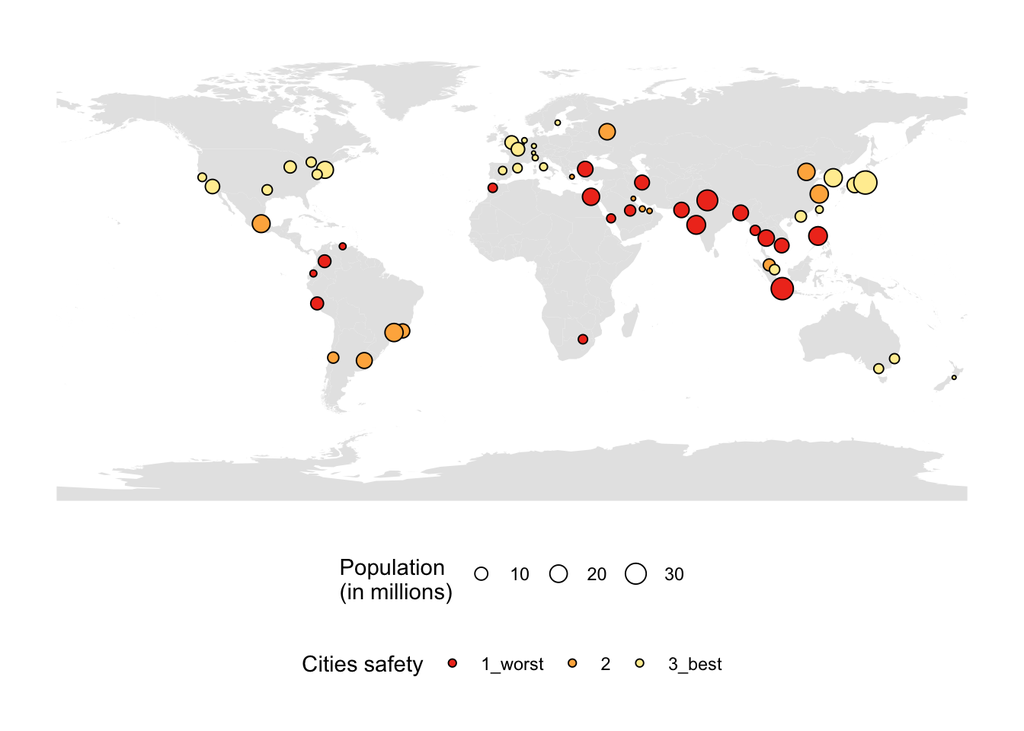

```r
points +     theme(legend.position="bottom",
          legend.box = "vertical") #+ guides(fill=FALSE)
```